# Proportional multi-state multiple-cohort life table model

Belen Zapata-Diomedi,Alan Both, Ali Abbas

03 November, 2021

# 1 Introduction

The proportional multi-state multiple-cohort life table model (PMSLT) is a population level model (macro) approach to simulate health (and economic) implications of changes in exposure to health risk factors (e.g. physical inactivity, air pollution and diet). The PMSLT has been widely used to simulate outcomes for population level interventions for chronic disease prevention.

The model was developed by Jan Barendregt and colleagues and has been widely used in Australia and New Zeland (1998, 2003).

The basic infrastructure of the model consist of three components: (1) Effect size for the intervention of interest (e.g. intervention to urban design that modifies population levels of physical activity); (2) Calculation of the potential impact fraction (PIF) to derive the change in occurrence of disease (incidence/case fatality) attributable to a change in the distribution of the risk factor (e.g. physical activity); and (3) Use of the PMSLT to simulate health (and economic) outcomes attributable to a change in the distribution of health risk factor/s in the population of interest. Figure 1.1 summaries the basic infrastructure of the model. ITHIM is included in Figure 1.1 to show that both approaches share in common steps one and two and differ in the mechanisms of calculation of change in health burden.

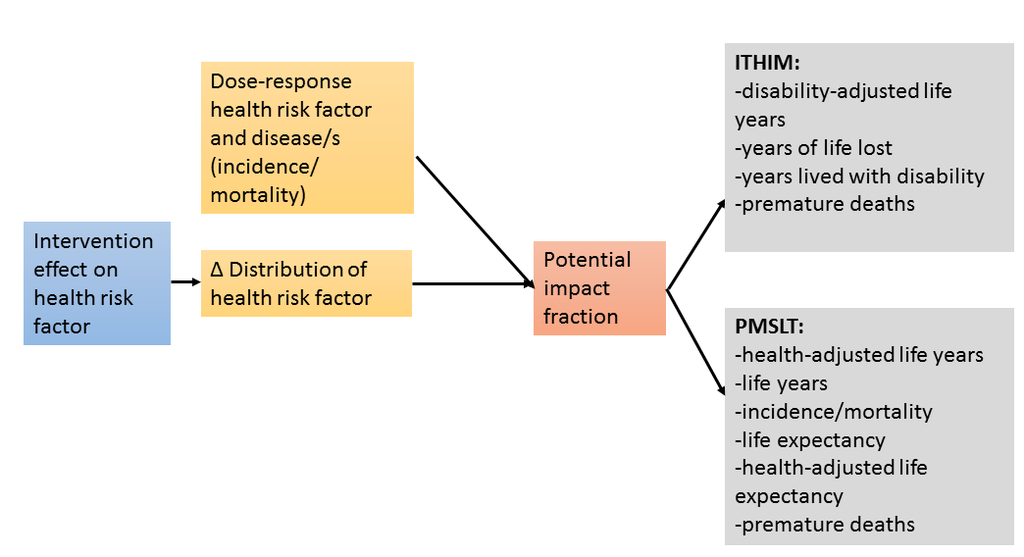

Figure 1.1: Basic ITHIMR infrastructure

**HALYs, QALYs and DALYs**

For the PMSLT model we use the term *health-adjusted life year* (HALY). As *summary measure of population health* it measures both quantity and quality of life, where one HALY represent the equivalent of one year in full health (which could be two years with a quality of life of 0.5, for example). Specific types of HALY are the quality-adjusted life year (QALY) and the disability-adjusted life year (DALY). The QALY derives from economics and was first used in the 1960s as a measure of health gain (Gold, Stevenson, and Fryback 2002). The disability-adjusted life-year (DALY) was developed for use in burden of disease studies as a measure of health loss due to disease (Murray and Acharya 1997). Our calculated HALYs are neither QALYs not DALYs, but something in between. They are similar to QALYs in that they represent health gains. However, the main difference is in the calculation of the health-related quality of life component. QALYs use measures of utility weights that traditionally represent individual experiences of health, whereas our estimated HALYs use disability weights linked to specific diseases, which were developed for the Global Burden of Disease study (Salomon et al. 2012). As discussed in past research (Cobiac, Vos, and Barendregt 2009) the main advantage of using disability weights over utility weights is that disability weights refer to specific diseases rather than health states (which are difficult to link to risk factors-e.g. physical inactivity). We opted to use the more general terms HALYs given that the use of the DALYs terminology may lead to think that our calculations are similar to those in burden of diseases studies. In our study, our model does not explicitly separate years of life lost (YLL) and years lived with disability (YLD) components, but instead calculates the total number of life years gained/lost due to an intervention, adjusted for the average health-related quality of life in those years (by age and sex). In burden of disease studies, DALYs are defined as the sum Years of Life Lost (YLL) and Years Lived with Disability (YLD).

# 2 Proportional multi-state multiple-cohort life table model

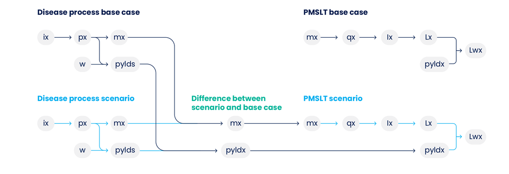

Figure 2.1: Analytical framework PMSLT

## 2.1 Disability weights

Disability weights (DW) are derived from disease specific prevalent years lived with disability (YLD) and disease specific prevalence by age group (5 years) and sex. Data for YLDs prevalence is from the Global Burden of Disease (GBD) data for 2017. An age and sex specific-correction was introduced to counteract the effects of accumulating co-morbid illnesses in the older age groups as shown in Equation (2.1). Interpolation was used to derive rates per single year of age from 5-year age intervals.

$$\begin{equation}
DW_{adjusted} = { { \frac{ { \frac{ { {YLD_{disease}}}} {P_{disease}} } } {1 - YLD_{total}}}}
\tag{2.1}
\end{equation}$$

Where YLD<sub>disease</sub> is the YLD mean number per age and sex for a given disease, P<sub>disease</sub> is the prevalence as reported in the Global Burden of Disease study for a given disease by age and sex and YLD<sub>total</sub> is the total YLD rate per age and sex

## 2.2 PIF for type 2 diabetes

$$\begin{equation}
PIF = { \frac{ -({ Prevalence_{scenario} - Prevalence_{base case}}) * (RR - 1)} {Prevalence_{base case} * (RR -1) +1}}
\tag{2.2}
\end{equation}$$

where Prevalence<sub>scenario</sub> represents the prevalence of type 2 diabetes after the scenario, whilst Prevalence~base case~ represents the prevalence for type 2 diabetes in the base case and Relative Risk (RR) represent the relative risk for stroke or ischemic heart disease respectively.

# 3 Generation of inputs for the proportional multi-state life table (PMSLT)

Table 3.1: PMSLT inputs

[output not shown]

## 3.1 Code

Table 3.2 is an overview of inputs, outputs and code for the generation of data inputs.

Table 3.2: Inputs and outputs

R file

Function

Input variable

Input file

Output variable

Saved file

prepare_GEO.R

GetGEO

data_local

mh-execute/input/mh_regions_lad_lookup.csv

local_goverment_areas

NA

organise_GBD.R

GetGBD

1. path 2) local_goverment_area

mh-mslt/input/gbd/GBD2017/METAHIT/; local_goverment_areas (calculated with GetGEO)

gbd

NA

get_disease_names.R

GetDiseaseTable

disease_names_execute

mh-execute/inputs/dose_response/disease_outcomes_lookup.csv

DISEASE_SHORT_NAMES

mh-mslt/output/paramters/DISEASE_SHORT_NAMES

prepare_GBD.R

calculateGBDwider

1. gbd 2) local_government_area

gbd (calculated with GetGBD) and local_goverment_areas (calculated with GetGEO)

gbd_wider

NA

prepare_GBD.R

calculateMSLT

1. gbd_wider (calculated with calculateGBDWider) 2) location_disease (calculated with GetDiseaseTable)

gbd_wider, location (cityregion) and DISEASE_SHORT_NAMES

mslt_df_wider

mh-execute/inputs/mslt

The below code generates inputs for: United Kingdom, England, Wales, Northern Ireland, Scotland, Wales, English regions (East Midlands, East of England, Greater London, North East England, North West England, South East England, South West England, West Midlands, Yorkshire and the Humber) and the English City Regions (Liverpool, Nottingham, Bristol, Northeast, Greater Manchester, Sheffield, West Midlands, Leeds and London). Raw inputs are in “inputs” folder. Processed data is in “output” folder. Final data save in mh-execute inputs/mslt. Intermediate files are not saved. *GBD will update data end of October*

### 3.1.1 Map local authorities to city regions

Use **GetGEO** to map between local authorities and city regions, and add names for regions that are not city regions (i.e. countries and regions of England). For the city regions we add up data available for lower and upper tier local authority areas. This is an intermediate step to be used in code that follows.

```r
source("~/mh-mslt/R/prepare_GEO.R")
data_local <- read_csv("~/mh-execute/inputs/mh_regions_lad_lookup.csv")
local_government_areas <- GetGEO(data_local)
head(local_government_areas)
```

### 3.1.2 Map geographical are to GBD names

Use **GetGBD** to map local_government_areas names to GBD input data names. Read original GBD data for 2017 and map to local government area. This step is required to map local government areas to gbd data and then to city regions. This is an intermediate step to be used in code that follows.

UPDATE with new release Oct 2020. DISBAYES INPUTS WILL ALSO NEED UPDATING. DISCUSS WITH TEAM.

```r
source("~/mh-mslt/R/organise_GBD.R")
gbd <- getGBD(path = "~/mh-mslt/input/gbd/GBD2017/METAHIT", local_government_areas)
head(gbd)
```

### 3.1.3 Diseases and non-diseases coding table

The disease coding table adds information to *metahit-execute file disease_outcomes_lookup.csv* to be able to run the PMSLT. The file disease_outcomes_lookup.csv was designed to match relative risks from for the included risk factors (physical activity, air pollution, noise) to diseases **GetDiseaseTable** adds information for all the diseases for which we derived input data, adds road injuries, classifies diseases to be modeled as diseases (chronic diseases such as stroke) and non-diseases (injuries), this is necessary as chronic diseases and injuries are modeled differently. We classified all-cause mortality as non-diseases since we are not including all-cause mortality risk reduction in the PMSLT (MAY CHANGE). Since PIFs have not yet been calculated for all diseases, we also include a variable indicating whether the disease has PIF or not. Lastly, a classification was made for diseases for males only or females only. The output is saved to be used when running the PMSLT in mh-execute.

```r
source("~/mh-mslt/R/get_disease_names.R")
disease_names_execute=read_xlsx("~/mh-execute/inputs/dose_response/disease_outcomes_lookup_2.xlsx")
DISEASE_SHORT_NAMES <- GetDiseaseTable(disease_names_execute)

head(DISEASE_SHORT_NAMES)

saveRDS(DISEASE_SHORT_NAMES, "~/mh-mslt/output/parameters/DISEASE_SHORT_NAMES.rds")
```

## 3.2 Data processing

Steps and code to generate inputs to run PMSLT from above generated files: gbd, local_goverment_areas and DISEASE_SHORT_NAMES.

### 3.2.1 Calculate baseline data by area

Original GBD data tidy up with **GBDwider** for later processing for PMSLT dataframe and disbayes inputs. Generates dataframe for all areas (city regions, UK, countries and English Regions). Inputs are by age (5-year groups) and sex. Intermediate data.

```r
source("~/mh-mslt/R/prepare_GBD.R")

gbd_wider <- calculateGBDwider(gbd = gbd, local_government_areas = local_government_areas)
head(gbd_wider)
```

## 3.3 Calculate baseline data for PMSLT

A PMSLT dataframe of inputs using **CalculateMSLT** is generated from above dataframe by single year of age and adding Disbayes outputs. Disbayes output generated by Chris J. Data saved in input folder of mh-execute.

```r
source("~/mh-mslt/R/prepare_GBD.R")

### Please check commnent manual entry for function calculateMSLT
### Load disbayes data
load("~/mh-mslt/input/city regions/Output disbayes/cityregions_smoothed_res.rda")

mslt_inputs <- list()
index <- 1
for (loc in unique(local_government_areas$cityregion)) {

mslt_inputs[[index]] <- calculateMSLT(gbd_wider, location = loc , disease)

names(mslt_inputs)[index] <- paste0(loc)

write.csv(mslt_inputs[[index]], file=paste0("~/mh-execute/inputs/mslt/", loc, "_mslt",".csv")) ### save to use in mh-excute


index <- index + 1

}
```

# 4 Code explained to run the PMSLT for one area (e.g. city regions, country);

## 4.1 Inputs

1. mslt_df: above generated.
2. model parameters: age and sex cohort.
3. pifs: generated in mh-execute
4. relative risks diabetes: from literature

### 4.1.1 Define model parameters

```r
i_age_cohort <-  c(17, 22, 27, 32, 37, 42, 47, 52, 57, 62, 67, 72, 77, 82, 87, 92, 97)
i_sex <- c('male', 'female')
```

### 4.1.2 Get potential impact fractions from mh-execute

Pifs are used in the scenario and non-disease (road injuries and lower respiratory disease) disease processes to modify incidence of diseases and mortality and yld rates for non-diseases (injuries and lower respiratory diseases). For now this is place holder. We can generate pifs as an outcome of mh-execute and save in mslt-repo to run independently for each of the city regions. The code below expands input pifs from 5-year age groups to one-year age groups. This is done to facilitate working with the mslt data in one-year age groups. Names of original pifs are also changed to match mslt inputs. This file is not saved, and use in later code.

```r
pif_expanded <- read_csv("~/mh-mslt/input/pif.csv") %>% ## PLACE HOLDER
  mutate(age_cat = case_when(age_cat =="16-19" ~ 17, ### Create matching age cohort variable to match mslt_df input
                        age_cat =="20-24" ~ 22,
                        age_cat =="25-29" ~ 27,
                        age_cat =="30-34" ~ 32,
                        age_cat =="35-39" ~ 37,
                        age_cat =="40-44" ~ 42,
                        age_cat =="45-49" ~ 47,
                        age_cat =="50-54" ~ 52,
                        age_cat =="55-59" ~ 57,
                        age_cat =="60-64" ~ 62,
                        age_cat =="65-69" ~ 67,
                        age_cat =="70-74" ~ 72,
                        age_cat =="75-79" ~ 77,
                        age_cat =="80-84" ~ 82,
                        age_cat =="85-89" ~ 87,
                        age_cat =="90-94" ~ 92,
                        age_cat =="95-120" ~ 97)) %>%
                  dplyr::rename(pif_ihd=scen_pif_pa_ap_noise_no2_ihd, ### rename all original pif columnst to match diseases
                  pif_stroke=scen_pif_pa_ap_stroke,
                  pif_colon=scen_pif_pa_colon,
                  pif_t2d=scen_pif_pa_t2d,
                  pif_endo=scen_pif_pa_endo,
                  pif_lc=scen_pif_pa_ap_lc,
                  pif_lri_deaths=scen_pif_ap_lri,
                  pif_copd=scen_pif_ap_copd,
                  pif_breast=scen_pif_pa_breast,
                  pif_cyclist_deaths=scen_cyclist_Fatal,
                  pif_pedestrian_deaths=scen_pedestrian_Fatal,
                  pif_cyclist_ylds=scen_cyclist_Serious,
                  pif_pedestrian_ylds=scen_pedestrian_Serious,
                  pif_motor_deaths='scen_car/taxi_Fatal',
                  pif_motorcyclist_deaths='scen_motorcycle_Fatal',
                  pif_motor_ylds='scen_car/taxi_Serious',
                  pif_motorcyclist_ylds=scen_motorcycle_Serious) %>%
                  mutate(pif_lri_ylds=pif_lri_deaths) %>% ###Repeat pif lri for deaths and ylds
                  dplyr::slice(rep(1:dplyr::n(), each = 5)) %>% ### expand to 1-yr group (repeat values)
                  mutate(age=rep(seq(16,100,1), times = 2))
```

### 4.1.3 Get relative risks for diabetes on cardiovascular diseases

Diabetes is a risk factor for cardiovascular diseases. Parametric and probabilistic inputs. To be included in metahit_functions.R Variables with normal distribution.

```r
### Parametric input
    DIABETES_IHD_RR_F <- 2.82 ## c(2.82, CI (2.35, 3.38) get SD from CI
    DIABETES_STROKE_RR_F <- 2.28 ## c(2.28) CI (1.93, 2.69) get SD from CI
    DIABETES_IHD_RR_M <- 2.16 ## c(2.16, CI (1.82, 2.56) get SD from CI
    DIABETES_STROKE_RR_M <- 1.83 ## c(1.83) CI (1.60, 2.08) get SD from CI

### Probabilistic input
# DIABETES_IHD_RR_F <- c(2.82, GetStDevRR(2.82, 2.35, 3.38))
# DIABETES_STROKE_RR_F <- c(2.28, GetStDevRR(2.28, 1.93, 2.69))
# DIABETES_IHD_RR_M <- c(2.16, GetStDevRR(2.16, 1.82, 2.56))
# DIABETES_STROKE_RR_M <- c(1.83, GetStDevRR(1.83, 1.60, 2.08))
```

### 4.1.4 Run base case general life table

Inputs for a general life table are population numbers and mortality rates. The below process life tables with life year, health-adjusted life years, life expectancy and health-adjusted life expectancy for each age and sex cohort for each city region. This code can be used independently if interested in life table analysis only. Select an area of interest. Options are: liverpool, nottingham, bristol, northeast, greatermanchester, sheffield westmidlands, leeds, london, United Kingdom, England, East Midlands, East of England, Greater London, North East England, North West England, South East England, South West England , West Midlands, Yorkshire and the Humber, Northern Ireland, Scotland, Wales. The example is for Bristol City Region.

NOTE: 1) mh-execute functions need updating with mh-mslt code; 2) Mortality trends not included.

```r
source("~/mh-mslt/R/functions_MSLT.R")

# dataframe of the age and sex cohorts (crossing just does a cross product) for loop below
  age_sex_cohorts <- crossing(data.frame(age=i_age_cohort),
                              data.frame(sex=c('male', 'female'))) %>%
    dplyr::mutate(cohort=paste0(age,"_",sex))

### Select inputs for area of interest

mslt_df <- mslt_inputs[["bristol"]]

 general_life_table_list_bl <- list()


  for (i in 1:nrow(age_sex_cohorts)){
    suppressWarnings(
      general_life_table_list_bl[[i]] <- RunLifeTable(
        in_idata    = mslt_df,
        in_sex      = age_sex_cohorts$sex[i],
        in_mid_age  = age_sex_cohorts$age[i],
        death_rates = NA ## mortality trends data if available, not for now. We would need trends for each city region.
      ))
    names(general_life_table_list_bl)[i] <- age_sex_cohorts$cohort[i]
  }

  # convert the list of dataframes to single dataframes
  general_life_table_bl <- bind_rows(general_life_table_list_bl, .id = "age_group") %>%
    mutate(age_group = as.numeric(gsub("_.*","",age_group)))
```

### 4.1.5 Run base case disease processes

NOTE: 1) mh-execute functions need updating with mh-mslt code; 2) Mortality trends not included.

```r
source("~/mh-mslt/R/functions_MSLT.R")


  disease_cohorts <- DISEASE_SHORT_NAMES %>%
    # Exclude non-diseases, road injuries, and diseases with no pif
    dplyr::filter(is_not_dis == 0 & acronym != 'no_pif' & acronym != 'other' ) %>%
    dplyr::select(sname,acronym,males,females)

  # adding the age and sex cohorts:
  age_sex_disease_cohorts <- crossing(age_sex_cohorts,disease_cohorts) %>%
    mutate(cohort=paste0(age,'_',sex,'_',sname)) %>%
    # Exclude non-male diseases (and non-female if there were any)
    filter( (sex=='male' & males==1) | (sex=='female' & females==1)) %>%
    dplyr::select(age,sex,sname,acronym,cohort) %>%
    # ishd and strk have the prerequisite disease dmt2
    mutate(prerequsite=ifelse(sname %in% c("ishd","strk"),paste0(age,"_",sex,"_dmt2"),0)) %>%
    # ensuring prequisites are calculated first
    arrange(age,sex,prerequsite,sname)


  disease_life_table_list_bl <- list()

  for (i in 1:nrow(age_sex_disease_cohorts)){
    disease_life_table_list_bl[[i]] <- RunDisease(
      in_idata         = mslt_df,
      in_mid_age       = age_sex_disease_cohorts$age[i],
      in_sex           = age_sex_disease_cohorts$sex[i],
      in_disease       = age_sex_disease_cohorts$sname[i],
      incidence_trends = NA,
      mortality_trends = NA
    )
    names(disease_life_table_list_bl)[i] <- age_sex_disease_cohorts$cohort[i]
  }
```

### 4.1.6 Run base case non-disease processes

```r
source("~/mh-mslt/R/functions_MSLT.R")

  non_disease_cohorts <- DISEASE_SHORT_NAMES %>%
    # Exclude non-diseases, road injuries, and diseases with no pif
    dplyr::filter(is_not_dis == 1 & acronym != 'no_pif' & acronym != 'other' ) %>%
    dplyr::select(sname,acronym,males,females)

  # adding the age and sex cohorts:
  age_sex_non_disease_cohorts <- crossing(age_sex_cohorts,non_disease_cohorts) %>%
    mutate(cohort=paste0(age,'_',sex,'_',sname)) %>%
    dplyr::select(age,sex,sname,acronym,cohort)

  non_disease_life_table_list_bl <- list()

  for (i in 1:nrow(age_sex_non_disease_cohorts )){

    non_disease_life_table_list_bl[[i]] <- RunNonDisease(
      in_idata         = mslt_df,
      in_sex           = age_sex_non_disease_cohorts$sex[i],
      in_mid_age       = age_sex_non_disease_cohorts$age[i],
      in_non_disease   = age_sex_non_disease_cohorts$sname[i]
    )
    names(non_disease_life_table_list_bl)[i] <- age_sex_non_disease_cohorts$cohort[i]
  }
```

### 4.1.7 Run scenarios diseases processes

Re run diseases processes with modified incidence rates by the pif. New incidence rates = bl incidence rates * (1-disease_pif).

```r
source("~/mh-mslt/R/functions_MSLT.R")


  disease_relative_risks <- tribble(
    ~sex    , ~prerequsite, ~disease , ~relative_risk       ,
    "male"  ,  "dmt2"     ,  "ishd"  ,  DIABETES_IHD_RR_M   ,
    "female",  "dmt2"     ,  "ishd"  ,  DIABETES_IHD_RR_F   ,
    "male"  ,  "dmt2"     ,  "strk"  ,  DIABETES_STROKE_RR_M,
    "female",  "dmt2"     ,  "strk"  ,  DIABETES_STROKE_RR_F
  )

  disease_life_table_list_sc <- list()

  for (i in 1:nrow(age_sex_disease_cohorts)){
    # i=6
    td1_age_sex <- mslt_df %>% ### new mslt dataframe with modified incidence rates
      filter(age >= age_sex_disease_cohorts$age[i] & sex == age_sex_disease_cohorts$sex[i])

    pif_colname <- paste0('pif_',age_sex_disease_cohorts$acronym[i])

    pif_disease <- pif_expanded %>%
      filter(age >= age_sex_disease_cohorts$age[i] & sex == age_sex_disease_cohorts$sex[i]) %>%
      dplyr::select(age,sex,pif_colname)

    # adjustment for diabetes effect on ihd and stroke
    if(age_sex_disease_cohorts$prerequsite[i] != 0){
      # get name for pif column
      target_disease <- paste0("pif_",age_sex_disease_cohorts$acronym[i])
      # get prerequisite disease cohort name (i.e., age_sex_dmt2 for diabetes)
      dia_col <- age_sex_disease_cohorts$prerequsite[i]
      # select relative risk of disease given diabetes (depends on sex, not age)
      relative_risk <- disease_relative_risks %>%
        filter(sex == age_sex_disease_cohorts$sex[i] &
                 disease == age_sex_disease_cohorts$sname[i]) %>%
        pull(relative_risk)
      # (store old pif)
      # old_pif <- pif_disease[[target_disease]]
      # diabetes pif = - { scenario prevalence - baseline prevalence } * (RR - 1)  / { baseline prevalence * (RR - 1) + 1 }
      scenario_prevalence <- disease_life_table_list_sc[[dia_col]]$px
      baseline_prevalence <- disease_life_table_list_bl[[dia_col]]$px
      pif_dia <- -(scenario_prevalence - baseline_prevalence)*(relative_risk-1)/
        (baseline_prevalence * (relative_risk-1) + 1)
      # modify pif for target disease: new pif =  (1 - old pif) * (1 - diabetes pif)
      pif_disease[[target_disease]] <- 1- (1-pif_disease[[target_disease]]) * (1-pif_dia)
      # print(sum(old_pif-pif_disease[[target_disease]]))
    }

    incidence_colname <- paste0('incidence_', age_sex_disease_cohorts$sname[i])
    new_col <- td1_age_sex%>%pull(incidence_colname) * (1 - (pif_disease%>%pull(pif_colname)))
    new_col[is.na(new_col)] <- 0
    td1_age_sex[[incidence_colname]] <- new_col

    ## Instead of idata, feed td to run scenarios. Now all diseases are run again, with the effect of diabetes
    ## on cardiovascular diseases taken into account.

    disease_life_table_list_sc[[i]] <- RunDisease(
      in_idata         = td1_age_sex,
      in_sex           = age_sex_disease_cohorts$sex[i],
      in_mid_age       = age_sex_disease_cohorts$age[i],
      in_disease       = age_sex_disease_cohorts$sname[i],
      incidence_trends = NA,
      mortality_trends = NA
    )
    names(disease_life_table_list_sc)[i] <- age_sex_disease_cohorts$cohort[i]
  }



  for (cohort in age_sex_disease_cohorts$cohort) {
    disease_life_table_list_sc[[cohort]]$diff_inc_disease <-
      disease_life_table_list_sc[[cohort]]$incidence_disease - disease_life_table_list_bl[[cohort]]$incidence_disease

    disease_life_table_list_sc[[cohort]]$diff_prev_disease <-
      disease_life_table_list_sc[[cohort]]$px - disease_life_table_list_bl[[cohort]]$px

    disease_life_table_list_sc[[cohort]]$diff_mort_disease <-
      disease_life_table_list_sc[[cohort]]$mx - disease_life_table_list_bl[[cohort]]$mx

    disease_life_table_list_sc[[cohort]]$diff_pylds_disease <-
      (disease_life_table_list_sc[[cohort]]$px - disease_life_table_list_bl[[cohort]]$px) *
      (disease_life_table_list_bl[[cohort]]$dw_disease)
  }


  # convert the list of dataframes to single dataframes
  disease_life_table_bl <- bind_rows(disease_life_table_list_bl, .id = "age_sex_disease_cohort") %>%
    mutate(age_sex_disease_cohort = as.numeric(gsub("_.*","",age_sex_disease_cohort))) %>%
    dplyr::rename(age_group=age_sex_disease_cohort,
           cause=disease)

  disease_life_table_sc <- bind_rows(disease_life_table_list_sc, .id = "age_sex_disease_cohort") %>%
    mutate(age_sex_disease_cohort = as.numeric(gsub("_.*","",age_sex_disease_cohort))) %>%
   dplyr::rename(age_group=age_sex_disease_cohort,
           cause=disease)
```

### 4.1.8 Run scenarios non-diseases processes

Re run non_diseases life tables with modified mortality and ylds rates by the pif. New rates = bl rates * (1-non_disease_pif). TO DO: CHECK CALCULATIONS OF NON DISEASE PIFS. CALCULATION SCENARIO_NUMBERS/BASELINE_NUMBER?

```r
source("~/mh-mslt/R/functions_MSLT.R")
    non_disease_life_table_list_sc <- list()

   for (i in 1:nrow(age_sex_non_disease_cohorts)){
    # i=6
    td1_age_sex <- mslt_df %>% ### new mslt dataframe with modified injuries and lri deaths and ylds rates
      filter(age >= age_sex_non_disease_cohorts$age[i] & sex == age_sex_non_disease_cohorts$sex[i])

    pif_colname_deaths <- paste0('pif_',age_sex_non_disease_cohorts$acronym[i], '_deaths')
    pif_colname_ylds <- paste0('pif_',age_sex_non_disease_cohorts$acronym[i], '_ylds')

    pif_non_disease <- pif_expanded %>%
      filter(age >= age_sex_non_disease_cohorts$age[i] & sex == age_sex_non_disease_cohorts$sex[i]) %>%
      dplyr::select(age,sex,pif_colname_deaths,pif_colname_ylds)


    death_colname <- paste0('deaths_rate_', age_sex_non_disease_cohorts$sname[i])
    ylds_colname <- paste0('ylds_rate_', age_sex_non_disease_cohorts$sname[i])


    new_deaths <- td1_age_sex%>%pull(death_colname) * (1 - (pif_non_disease%>%pull(pif_colname_deaths)))
    new_deaths[is.na(new_deaths)] <- 0

    new_ylds <- td1_age_sex%>%pull(ylds_colname) * (1 - (pif_non_disease%>%pull(pif_colname_ylds)))
    new_ylds[is.na(new_ylds)] <- 0

    td1_age_sex[[death_colname]] <- new_deaths
    td1_age_sex[[ylds_colname]] <- new_ylds

    ## Instead of idata, feed td to run scenarios. Now all non_diseases are run again


    non_disease_life_table_list_sc[[i]] <- RunNonDisease(
      in_idata         = td1_age_sex,
      in_sex           = age_sex_non_disease_cohorts$sex[i],
      in_mid_age       = age_sex_non_disease_cohorts$age[i],
      in_non_disease   = age_sex_non_disease_cohorts$sname[i]
    )
    names(non_disease_life_table_list_sc)[i] <- age_sex_non_disease_cohorts$cohort[i]

  }

  ### Difference rates

   for (cohort in age_sex_non_disease_cohorts$cohort) {
     non_disease_life_table_list_sc[[cohort]]$diff_mort <-
       non_disease_life_table_list_sc[[cohort]]$deaths_rate -  non_disease_life_table_list_bl[[cohort]]$deaths_rate

     non_disease_life_table_list_sc[[cohort]]$diff_pylds <-
        non_disease_life_table_list_sc[[cohort]]$ylds_rate -  non_disease_life_table_list_bl[[cohort]]$ylds_rate }



  # convert the list of dataframes to single dataframes
  non_disease_life_table_bl <- bind_rows(non_disease_life_table_list_bl, .id = "age_sex_non_disease_cohort") %>%
    mutate(age_sex_non_disease_cohort = as.numeric(gsub("_.*","",age_sex_non_disease_cohort))) %>%
    dplyr::rename(age_group=age_sex_non_disease_cohort,
           cause=non_disease,
           mx=deaths_rate)

  non_disease_life_table_sc <- bind_rows(non_disease_life_table_list_sc, .id = "age_sex_non_disease_cohort") %>%
    mutate(age_sex_non_disease_cohort = as.numeric(gsub("_.*","",age_sex_non_disease_cohort))) %>%
    dplyr::rename(age_group=age_sex_non_disease_cohort,
           cause=non_disease,
           mx=deaths_rate)
```

### 4.1.9 Collect changes in mortality and prevalent years lived with disability.

```r
### Diseases: Sum mortality rate and pylds change scenarios
  mx_pylds_sc_total_disease_df <- disease_life_table_sc %>%
    group_by(age_group,sex,age) %>%
    dplyr::summarise(mortality_sum=sum(diff_mort_disease,na.rm=T),
              pylds_sum=sum(diff_pylds_disease,na.rm=T)) %>%
    ungroup() %>%
    mutate(age_sex_cohort=paste0(age_group,'_',sex))

### Non-diseases
  mx_pylds_sc_total_non_disease_df <- non_disease_life_table_sc %>%
    group_by(age_group,sex,age) %>%
    dplyr::summarise(mortality_sum=sum(diff_mort,na.rm=T),
              pylds_sum=sum(diff_pylds,na.rm=T)) %>%
    ungroup() %>%
    mutate(age_sex_cohort=paste0(age_group,'_',sex))
```

### 4.1.10 Run scenario life table

General life table re-run with modified mortality and Pylds rates

```r
  general_life_table_list_sc <- list()

  for (i in 1:nrow(age_sex_cohorts)){
    # modify idata's mortality and pyld total for the said scenario
    mx_pylds_sc_total_disease_df_cohort <- mx_pylds_sc_total_disease_df %>%
      filter(age_sex_cohort==age_sex_cohorts$cohort[i]) %>%
      dplyr::select(age,mortality_sum,pylds_sum)

       mx_pylds_sc_total_non_disease_df_cohort <- mx_pylds_sc_total_non_disease_df %>%
      filter(age_sex_cohort==age_sex_cohorts$cohort[i]) %>%
      dplyr::select(age,mortality_sum,pylds_sum)

    ### Modify rates in static MSLT  (pylds are always static, mx can include future trends)
    #### With diseases changes in mortality and ylds
    td2 <- mslt_df %>%
      filter(sex==age_sex_cohorts$sex[i]) %>%
      left_join(mx_pylds_sc_total_disease_df_cohort,by="age") %>%
      mutate(mx=mx+replace_na(mortality_sum,0),
             pyld_rate=pyld_rate+replace_na(pylds_sum,0)) %>%
      dplyr::select(-mortality_sum,-pylds_sum)

    #### With diseases changes in mortality and ylds
    td3 <-  td2 %>%
      filter(sex==age_sex_cohorts$sex[i]) %>%
      left_join(mx_pylds_sc_total_non_disease_df_cohort,by="age") %>%
      mutate(mx=mx+replace_na(mortality_sum,0),
             pyld_rate=pyld_rate+replace_na(pylds_sum,0)) %>%
      dplyr::select(-mortality_sum,-pylds_sum)

    # ### Modify death rates with future trends NOT AVAILABLE FOR METAHIT
    # td3 <- death_projections %>%
    #   mutate(cohort=paste(age_cohort, sex, sep = "_")) %>% # variable to match change in mortality rates df
    #   filter(cohort==age_sex_cohorts$cohort[i]) %>%
    #   left_join(mx_pylds_sc_total_disease_df_cohort) %>%
    #   mutate(rate=rate+replace_na(mortality_sum,0))%>%
    #   dplyr::select(-mortality_sum,-pylds_sum)



    suppressWarnings(
      general_life_table_list_sc[[i]] <- RunLifeTable(
        in_idata    = td3,
        in_sex      = age_sex_cohorts$sex[i],
        in_mid_age  = age_sex_cohorts$age[i],
        death_rates = NA
      ))
    names(general_life_table_list_sc)[i] <- age_sex_cohorts$cohort[i]
  }

  # convert the list of dataframes to single dataframes
  general_life_table_sc <- bind_rows(general_life_table_list_sc, .id = "age_group") %>%
    mutate(age_group = as.numeric(gsub("_.*","",age_group)))
```